# Ejemplo Básico de R Markdown

Alexis Naranjo

2025-06-10

# Introducción

## Título en rojo (nivel 2)

### Subtítulo azul en negrita (nivel 3)

# Introducción

Este documento es un ejemplo básico de cómo usar **R Markdown** para generar reportes en **HTML**.

*R Markdown* permite combinar código R, texto, y resultados en un solo documento reproducible.

## ¿Qué es R Markdown?

R Markdown es una herramienta del ecosistema R que permite:

- Combinar código y texto
- Documentar análisis reproducibles
- Exportar en múltiples formatos: HTML, PDF, Word, etc.

A continuación veremos un ejemplo completo que incluye:

1. Texto explicativo
2. Código R
3. Gráficos
4. Análisis básico

## Encabezado de Nivel 2: Configuración Inicial

## Exploración del dataset mtcars

El dataset mtcars viene por defecto en R y contiene datos de consumo de combustible y otras características de automóviles.

### Vista previa de los datos

Primeras filas del dataset mtcars

|  | mpg | cyl | disp | hp | drat | wt | qsec | vs | am | gear | carb |
| --- | --- | --- | --- | --- | --- | --- | --- | --- | --- | --- | --- |
| Mazda RX4 | 21.0 | 6 | 160 | 110 | 3.90 | 2.620 | 16.46 | 0 | 1 | 4 | 4 |
| Mazda RX4 Wag | 21.0 | 6 | 160 | 110 | 3.90 | 2.875 | 17.02 | 0 | 1 | 4 | 4 |
| Datsun 710 | 22.8 | 4 | 108 | 93 | 3.85 | 2.320 | 18.61 | 1 | 1 | 4 | 1 |
| Hornet 4 Drive | 21.4 | 6 | 258 | 110 | 3.08 | 3.215 | 19.44 | 1 | 0 | 3 | 1 |
| Hornet Sportabout | 18.7 | 8 | 360 | 175 | 3.15 | 3.440 | 17.02 | 0 | 0 | 3 | 2 |
| Valiant | 18.1 | 6 | 225 | 105 | 2.76 | 3.460 | 20.22 | 1 | 0 | 3 | 1 |

## Análisis estadístico básico

Vamos a calcular estadísticas descriptivas básicas para algunas variables.

| media_mpg | mediana_mpg | sd_mpg | media_hp | mediana_hp | sd_hp | media_wt | mediana_wt | sd_wt |
| --- | --- | --- | --- | --- | --- | --- | --- | --- |
| 20.09062 | 19.2 | 6.026948 | 146.6875 | 123 | 68.56287 | 3.21725 | 3.325 | 0.9784574 |

## Visualización de datos

Vamos a realizar un gráfico de dispersión para observar la relación entre el peso del vehículo y el consumo de combustible.

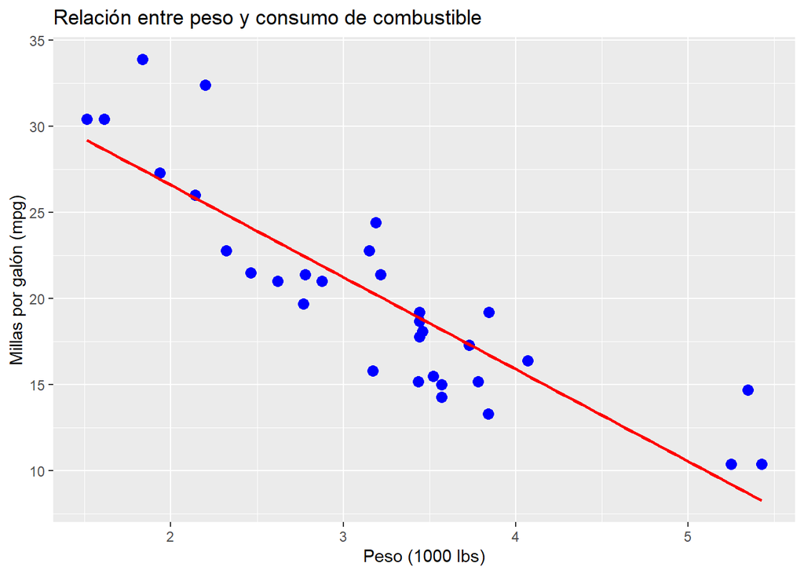

## Análisis final

Podemos observar que:

- Existe una relación negativa entre el peso del vehículo y el consumo de combustible.
- A mayor peso (wt), menor rendimiento (mpg).
- Esta relación es evidente en la recta de regresión añadida al gráfico.

Este tipo de análisis básico permite a los analistas comprender rápidamente patrones importantes en los datos.

## Conclusiones

- R Markdown es ideal para documentar análisis de forma clara y reproducible.
- Permite combinar texto, código y resultados en un solo archivo.
- Es muy útil en la elaboración de reportes profesionales y académicos.